# Longitudinal Analysis of Elderly Cognitive Training

Author

Suweda Said, Anna Moan

Published

November 6, 2026

Abstract

The ACTIVE (Advanced Cognitive Training for Independent and Vital Elderly), study sought to test whether interventions in memory, reasoning, and speed of processing could impove cognitive health outcomes in older adults. We modeled the effect of the intervention on reasoning scores over a five-year period using a linear mixed effects model. Though participants who received the intervention initially saw steeper gains in reasoning skills, after the three-year mark, their scores decreased at a faster rate than the control group, suggesting that the intervention produces significant gains in the short term, but effectiveness decreases in the long term.

## Introduction

Many elderly adults experience a decline in function as they age. Over the past decades, researchers have sought to address factors that influence this. Our analysis draws on a study focusing on whether the cognitive function of elderly adult can be improved with interventions. The data was collected in an experimental trial called “ACTIVE.” (Tennstedt and Unverzagt 2013). The ACTIVE study began in 1996, and continued for approximately 10 years, tracking repeated observations for subjects at several increments. The trial began with 2,082 participants age 65 or older, though some subjects passed away or left the study before the trial period was completed. The recorded measurements include patient characteristics, such as their baseline age, gender, education, and baseline scores. The participants were divided into 4 sub-groups: a control group, and 3 treatment groups, that measure Reasoning, Memory, and Processing Speed. These cognitive areas were selected because they show relatively early cognitive decline (Tennstedt and Unverzagt 2013). Our analysis narrows in on the reasoning intervention, which is intended to improve a person’s ability to solve problems containing a serial pattern. The treatment groups received specialized training over 5-6 weeks, a subset within these groups had also received additional booster training.

We specifically seek to understand how a the reasoning intervention affects participants’ reasoning scores over time, not just in the short term or in absolute terms, while controlling for other factors such as age at baseline, gender, and education.

## Data

In this study we will use data collected by researches at 6 institutions; Indiana School of Medicine, John Hopkins University, Pennsylvania State University, Wayne State University, Hebrew Senior Life, and the New England Research Institute (Rebok et al. 2014).

The variables of interest are years and intervention group (whether the participant received the training or not), with baseline age, gender, and years of education as confounders. We will focus on the “Reasoning” outcome measure, in further understanding the effects we will draw comparisons between the Reasoning and Control group.

The plot illustrates how the relationship between reasoning scores and is not linear across the trial period, and it is different depending on whether the participant is in the control group or intervention group.

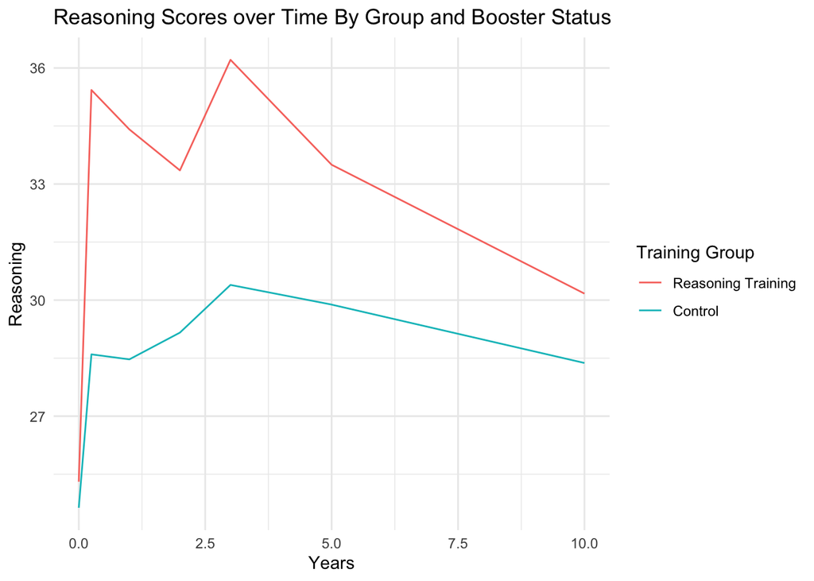

## Methods

We opted to use a Mixed Effect model to model how the relationship between intervention and reasoning scores changes over time. Because our preliminary plots showed that this relationship differed based on whether the participant was in the control group or intervention group, we added an interaction term with intervention group and years. Because the slope also changes dramatically before and after Year 3, we added another interaction term based on whether the observation was before or after the three-year mark. Because demographic factors such as gender, baseline age, and higher education can also affect cognition, we controlled for them. Thus, we had a linear model with a three-way interaction term between intervention group, years, and whether the observation was before/after Year 3.

Because our data is longitudinal, we cannot assume observations from the same person are uncorrelated. Thus, we fit two mixed-effects models: one allowing for random slopes and one allowing for both random slopes and intercepts. Random intercepts and slopes help account for correlation within a participants’ scores because if a participant begins with higher than average reasoning scores or a steeper than average slope, it follows that the rest of their scores will be distributed similarly.

All models were fit in R-Studio, using the lme4 package.

We will interpret various summary statistics, such as BIC, AIC, p-values, and correlation outputs to assess the effect combinations of explanatory variables (education, years, baseline age, gender) may have with the outcome (reasoning). Within our model we consider specifying specific time periods, before the 3 year mark and after the 3 year mark, this allows us to assess changes in the slope more clearly.

## Results

On average, the baseline scores of participants who received reasoning training were 2.81 points higher compared with those who did not (controlling for gender, years of education, and age at the beginning of the study). Among the intervention group before Year 3, reasoning scores increased by an additional 0.83 points with each year. This means that while scores increased for both groups within the first three years, they increased more steeply for the intervention group. After Year 3, however, reasoning scores among the intervention group decreased, by an additional 1.63 points on average compared with the control group. This means that after Year 3, while all participants’ scores decreased, the decrease was steeper among the intervention group.

When comparing our final model to a model without random slopes using an Anova test, the p-value is below 0.05, meaning we can reject the null hypothesis that the random slopes do not improve the model. Our final model has a BIC score of 41410, 4 points fewer than the candidate model, and an AIC of 41309, 18 points lower than the candidate. Metrics like AIC and BIC measure model fit, weighing accuracy with complexity, similar to a parsimonious penalty models with additional terms that do not explain the data better are penalized with a higher score.

The residuals of the final model appear relatively symmetrically distributed around $y=0$; however, the final model tends to slightly overestimate reasoning scores at the lower extreme and underestimate at the higher extreme.

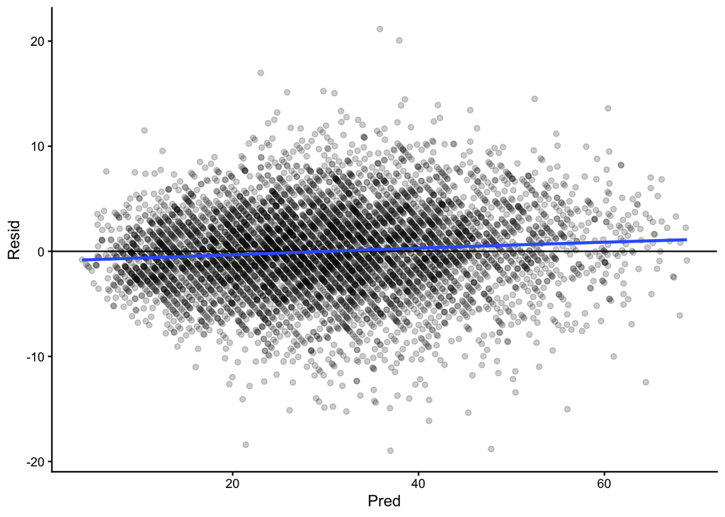

The Q-Q plot of the intercept and years shows that the distribution of our random effects is approximately normal, with some deviation toward the higher and lower extremes.

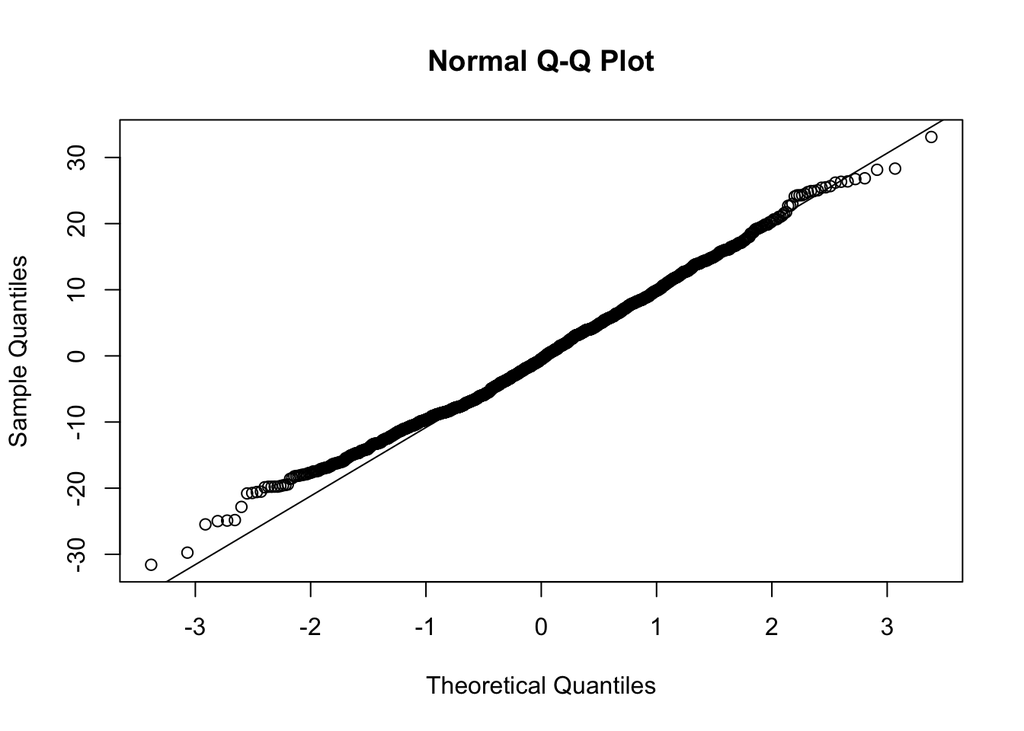

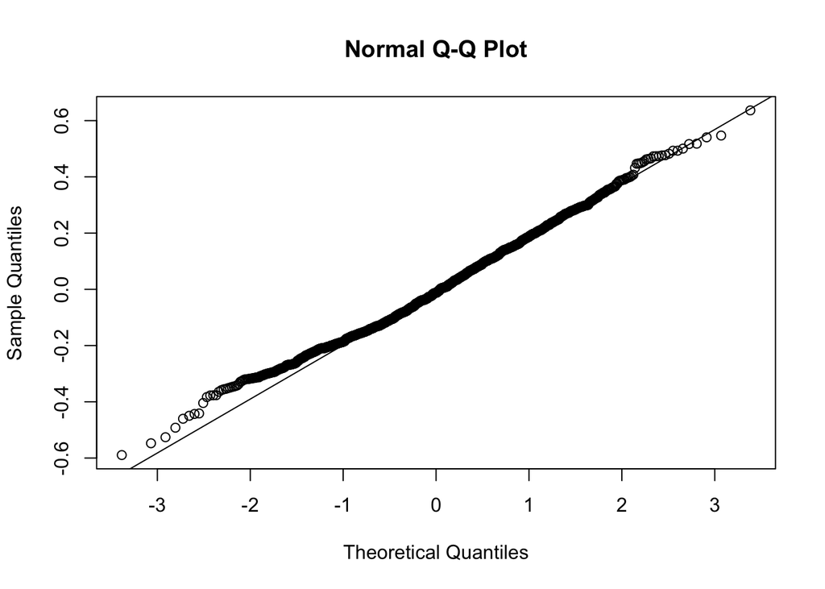

## Conclusions

There are several limitations to our conclusions. The ACTIVE study was composed of volunteers who were not necessarily representative of the general population, especially in age and education, and participants who were older with lower cognitive function were more likely to drop out. By only looking at the first five years of the study, we hoped to lessen the impact of attrition bias, but the greater missigness in the later years might still make it more difficult to generalize our findings.

In using a linear mixed-effects model, we assume a linear relationship between reasoning scores and years, which may not fully capture the shape of the data. LMMs also require us to drop or impute missing data, which may introduce bias if data is not missing at random. Additionally, the standard errors are only valid if the covariance model is correct.

## Acknowledgements

Thank you to Brianna!

## References

Rebok, George W, Karlene Ball, Lin T Guey, et al. 2014. “Ten-Year Effects of the ACTIVE Cognitive Training Trial on Cognition and Everyday Functioning in Older Adults.” *Journal of the American Geriatrics Society* 62 (1): 16.

Tennstedt, Sharon L, and Frederick W Unverzagt. 2013. “The ACTIVE Study: Study Overview and Major Findings.” *Journal of Aging and Health* 25 (8_suppl): 3S–20S.